# プロビット・ロジットモデルについて

山本雅資

2023-10-15

## 1. はじめに

回帰モデルの被説明変数が一定の範囲の値しか取らないモデルを**制限従属変数モデル**あるいは**離散選択モデル**と呼ぶ。出産を経験した女性が元の職場に戻る場合を1、戻らない場合を0とするような被説明変数を年収や教育で回帰する場合などがその例である。

また、アンケート調査の回答における満足度のように、5が最も満足度が高く、4,3,2,1と満足度が下がっていくような場合も特定の値しか取らない。この場合、数量的な大きさというよりも質的な関係を表しており、その順序が重要である。本稿で学ぶプロビット、ロジットモデルはそのような場合にも拡張可能で、**順序付きプロビット(ロジット)・モデル**と呼ばれている。

## 2. 理論的枠組み

### 線型回帰モデルの限界

出産後の女性が元の職場に戻るかどうかの意思決定$Y_i$が、$X_1$および$X_2$で線型回帰モデルで説明できるものとする。これは、以下のような線型確率モデルで表すことができる。

$$Y_i=\beta_0+\beta_1 X_{1i}+\beta_2 X_{2i}+u_i \tag{1}$$
この式は通常のOLSで推定可能であるが、推定結果$(=\hat{Y})$が一定の範囲に収まる保証はない。たとえば、被説明変数が$(0,1)$の範囲の確率であった場合に、$\hat{Y}=2$となった場合の解釈が困難である。そこで、以下のプロビットモデルおよびロジットモデルが登場する[^1]。

### ランダム効用モデル

経済学の視点からは、Daniel McFaddenのランダム効用モデルから離散選択モデルを解釈することが有用である。McFaddenは個人$i$が選択肢$j$を選んだ場合の効用$(=U_{ij})$は以下のようなランダムな関数と考えられるとした。

$$U_{ij}=\boldsymbol{X}_{ij}^{\prime} \beta+v_{ij} \tag{2}$$
ここで、$\boldsymbol{X}_{ij}$は個人$i$が選択肢$j$を選んだ場合の観察可能な属性の行列である。よって、ベクトル$\beta$は属性が効用に与える大きさを示す係数となる。最後に、ランダム効用モデルでは個人$i$の選択肢$j$を選んだ場合の効用は観測不可能な属性によっても影響を受けるものと考えており、これを$v_{ij}$で表す。

個人$i$がある選択をしたということはその選択肢を選んだ方が効用が高いためだと考える。$j \in (A,B)$の場合に、選択肢$A$が選ばれているとすれば、

$$U_{iA} > U_{iB} \tag{3}$$
が成立していると考えることが自然である。これを変形すると、

$$\boldsymbol{X}_{iA}^{\prime}
\beta+v_{iA}>\boldsymbol{X}_{iB}^{\prime} \beta+v_{iB} \tag{4}$$
さらに変形して、

$$v_{iA}-v_{iB}>-(\boldsymbol{X}_{iA}-\boldsymbol{X}_{iB})^{\prime}\beta
\tag{5}$$

$v_{iA}-v_{iB}$の分布について一定の仮定を置けば、$\beta$を推定することが可能になる。ランダム項に標準正規分布を仮定した場合はプロビットモデル、ガンベル分布を仮定した場合をロジットモデルと呼んでいる。

### プロビットモデル

平均が0、分散が1の正規分布のことを標準正規分布という。その確率密度関数は、以下の式で表される。

$$f(x) = \frac{1}{\sqrt{2\pi}} \exp{\left(-\frac{x^2}{2}\right)}
\hspace{20px} (-\infty < x < \infty) \tag{6}$$

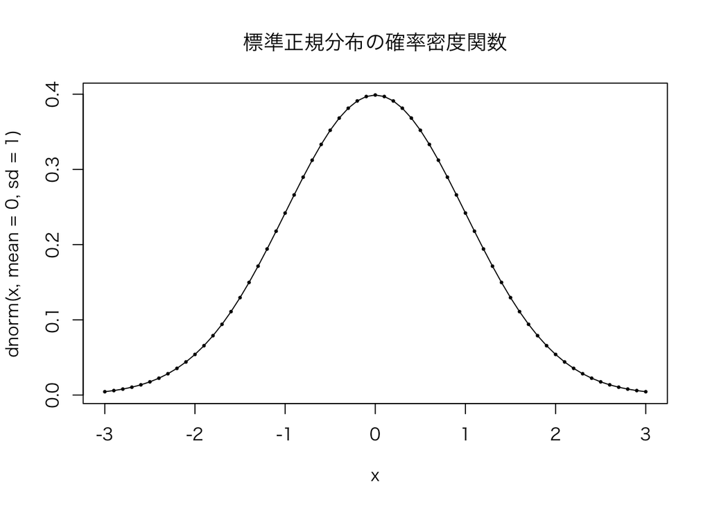

```r
par(family= "HiraKakuProN-W3")
x<-seq(from=-3, by=0.1,3 )
plot(x, dnorm(x, mean=0, sd=1), type="o",pch=20,cex=0.5,
     main="標準正規分布の確率密度関数") #確率密度関数
```

累積分布は確率密度関数を積分することで求めることができる。よって、

$$\Phi(x)=\int_{-\infty}^\infty f(t) dt \tag{7}$$
が標準正規分布の累積分布関数である。

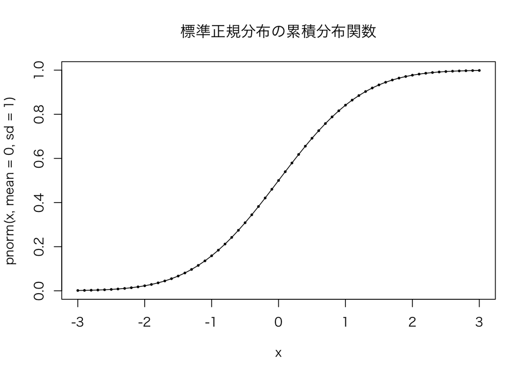

```r
par(family= "HiraKakuProN-W3")
x<-seq(from=-3, by=0.1,3 )
plot(x, pnorm(x, mean=0, sd=1), type="o",pch=20,cex=0.5,
     main="標準正規分布の累積分布関数") #累積分布関数
```

個人$i$によって選択肢$A$が選ばれた場合を、$y_i =1$と書くものとする。$v_{iA}-v_{iB}$が標準正規分布に従うとすれば、

$$\begin{aligned}
\Pr(y_i =1 |\boldsymbol{X}_{iA}, \boldsymbol{X}_{iB}
)&=\Pr(v_{iA}-v_{iB}>-(\boldsymbol{X}_{iA}-\boldsymbol{X}_{iB})^{\prime}\beta)
\\
&=\Pr(-(v_{iA}-v_{iB})<(\boldsymbol{X}_{iA}-\boldsymbol{X}_{iB})^{\prime}\beta)
\\
&=\Phi ((\boldsymbol{X}_{iA}-\boldsymbol{X}_{iB})^{\prime}\beta)
\end{aligned} \tag{8}$$
$(8)$式の最後の等号は、標準正規分布が左右対称であることを利用している。すなわち、$-h$よりも小さい確率と$h$よりも大きい確率は標準正規分布の確率密度関数において同じ面積なので、同じ確率の大きさとなる。これがプロピットモデルである。実証分析では、最尤推定法を用いて係数を推定する。

### ロジットモデル

ロジットモデルでは、ランダム項$v_{ij}$がガンベル分布に従うと仮定する。ガンベル分布の確率密度関数は、

$$f(v_{ij})=e^{-v_{ij}}e^{-e^{-v_{ij}}} \tag{9}$$
また、累積分布関数は、

$$F(v_{ij})=e^{-e^{-v_{ij}}} \tag{10}$$
であり、分散は$\frac{\pi^2}{6}$である。二つのガンベル分布に従う値の差はロジスティック分布することがわかっている。よって、

$$F(v_{iA}-v_{iB})=\frac{e^{v_{iA}-v_{iB}}}{1+e^{v_{iA}-v_{iB}}} \tag{11}$$
となり、(8)式より、

$$\Pr(y_i =1 |\boldsymbol{X}_{iA}, \boldsymbol{X}_{iB}
)=\frac{e^{v_{iA}-v_{iB}}}{1+e^{v_{iA}-v_{iB}}} \tag{12}$$
となる。これがロジットモデルである。ロジットモデルもプロビットモデルと同様に最尤推定法で係数を推定することができる。

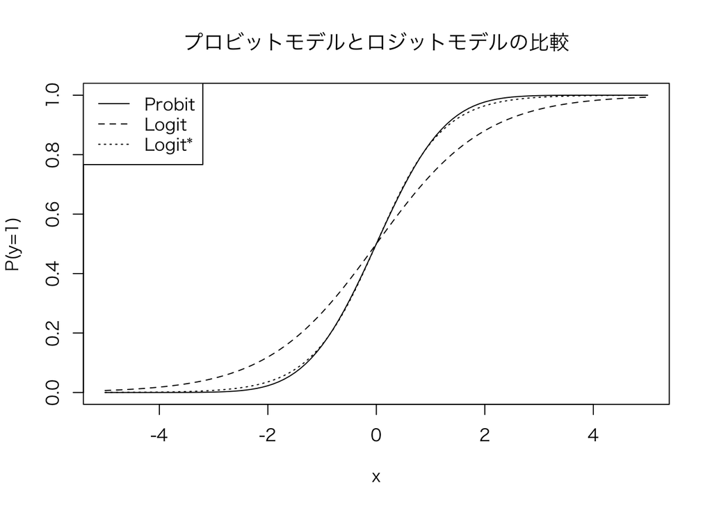

```r
# このコードは、里村(2010)に基づいています。
#２項ロジットモデルの関数の定義

blogit<-function(mu){
  Pr<-exp(mu)/(1+exp(mu))
  return(Pr)
}

beta0<-0
beta1<-1

x<-seq(-5,5,by=0.1)
y1<-pnorm(beta0+beta1*x)
y2<-blogit(beta0+beta1*x)
y3<-blogit(beta0+1.65*beta1*x)

par(family= "HiraKakuProN-W3")
plot(x,y1,type="l",lty=1,xlab="x",ylab="P(y=1)",xlim=c(-5,5),
     ylim=c(0,1), main="プロビットモデルとロジットモデルの比較")
lines(x,y2,lty=2)
lines(x,y3,lty=3)
legend("topleft",legend=c("Probit","Logit","Logit*"),lty=1:3)
```

上の図はプロビットモデルとロジットモデルの推定結果を示している。$x=0$付近ではプロビットもロジットも$\Pr(y_i =1)=\frac{1}{2}$という結果になっているが、$x<0$の範囲では、ロジットの方が高めの確率になっている。

里村(2010)のP75-6によれば、Amemiya(1981,JEL)の結果として、プロビットとロジットの結果を近づけたければ、ロジットの係数を1.65倍すれば良いとの記述がある。

### 多項ロジットモデル

これまでは選択肢が２つの場合を想定してきたが、実際の分析では３つ以上の選択肢の中から何かを選択する意思決定を行う問題にも多く直面する。ロジットモデル（プロビットモデルも）は３つ以上の選択肢についても拡張可能である。

個人$i$が$j \in (A,B,C)$という意思決定問題を考える。たとえば、McFaddenがランダム効用モデルを開発した際は、サンフランシスコにBART (Bay Area Rapid Transit)と呼ばれる鉄道を開業した場合の通勤の手段選択 (($A$)バスか($B$)BARTか($C$)自家用車か) の意思決定問題であった。バス(=選択肢$A$を基準として考えると、この意思決定問題は以下のようになる。

$$(\boldsymbol{X}_{iB}-\boldsymbol{X}_{iA})\prime
\beta+(v_{iB}-v_{iA})>\max
\{0,(\boldsymbol{X}_{iC}-\boldsymbol{X}_{iA}) \prime
\beta+(v_{iC}-v_{iA})\} \tag{13a}$$

ここで、

$$\boldsymbol{Z}_{iB}=\boldsymbol{X}_{iB}-\boldsymbol{X}_{iA}$$
および
$$\boldsymbol{Z}_{iC}=\boldsymbol{X}_{iC}-\boldsymbol{X}_{iA}$$
とおくと、多項ロジットモデルは以下のように書くことができる。

$$\Pr(y_i |\boldsymbol{Z}, \beta )=\frac{e^{\boldsymbol{Z}_{iB}\prime
\beta}}{1+e^{\boldsymbol{Z}_{iB}\prime
\beta}+e^{{\boldsymbol{Z}_{iC}\prime \beta}}} \tag{13b}$$
この問題は２値変数の場合と同様に最尤推定法で係数を推定することができる。

多項ロジットモデルの注意点としては、観察されない特性（$=v_{ij}$)に対するI.I.A. (Independent of Irrelevant Alternatives: 無関係な代替案から独立)の仮定がある。通勤手段選択において、バスか自家用車かという２つの選択肢しかない場合と、新たなにBARTが加わった場合で、$v_{ij}$は変化しないというものである。これは、BART建設のように新規選択肢の分析を容易にするが、意思決定問題のタイプによって適切ではない場合もある。

### 最尤推定法[^2]

$\Pr(y_i |\boldsymbol{X}_{i}; \beta)$という条件付き確率を考える。これは、個人$i$が$y_{i}=1$を選択するか、あるいは$y_{i}=0$を選択するかの確率は観測できる属性$(=\boldsymbol{X}_{i})$と係数$\beta$によって変化することを示している。

データが$n$人の意思決定を含むものとし、それぞれが独立に意思決定をしたとすると、この$n$人の実際の選択が起こる確率は、

$$\Pr(y_1 |\boldsymbol{X}_{1}; \beta) \times \Pr(y_2 |\boldsymbol{X}_{2};
\beta) \cdots \times \Pr(y_n |\boldsymbol{X}_{n}; \beta) \tag{14}$$
となる。これを以下のように書く。

$$\Pr(\boldsymbol{y}|\boldsymbol{X};\boldsymbol\beta)=\Pi_{i=1}^{n} \Pr
(y_i |\boldsymbol{X}_{i}; \boldsymbol\beta) \label{eq:14} \tag{15}$$

($\ref{eq:15}$)式の左辺を条件付き尤度 (conditional likelihood)と呼ぶ。最尤推定法は、条件付き尤度を最 大化するように (つまりモデルをできる限り観測データに即しているように) 係数$(\boldsymbol\beta)$を決定する。この尤度を最大化する係数を「最尤推定量(maximum likelihood estimator)」と呼ぶ。

($\ref{eq:15}$)式の対数を取ると、

$$\ln \Pr(\boldsymbol{y}|\boldsymbol{X};\boldsymbol\beta)=\ln
\left(\Pi_{i=1}^{n} \Pr (y_i |\boldsymbol{X}_{i}; \boldsymbol\beta)
\right)=\sum_{i=1}^{n} \ln \Pr (y_i |\boldsymbol{X}_{i};
\boldsymbol\beta) \label{eq:15} \tag{16}$$
となる。実際の推定においては、この対数を取った条件付き対数尤度の最大値を計算する。その理由は確率は必ず1よりも小さいため、掛け合わせる$n$が大きくなるとあっという間に小さな値となってしまい、コンピューターで正確に計算できないためである。($\ref{eq:16}$)式を係数$(\beta_1, \beta_2, \cdots, \beta_k)$で微分してゼロとおいた上で、ニュートン・ラフソン法などの数値的最適化で解を求める。

なお、($\ref{eq:16}$)式をさらに計算を進めると以下のようになる。

$$\ln \Pr(\boldsymbol{y}|\boldsymbol{X};\boldsymbol\beta)=-n \ln \sigma
-\frac{n}{2} \ln (2\pi) -\sum_{i=1}^{n} \frac{[y_i-\hat{y}_i]^2}{2
\sigma^2} \tag{17}$$
となる。この式の最大化を行うには、最後の項を最小化すれば良い。これは最小二乗法に他ならない。

実際の計算においては、対数尤度などを実際に書き下して計算する必要はなく、Rなどのソフトウェアを用いることで簡単に計算を行うことができる。

## 3. Rによる推定

以下では**R**の**mlogit**パッケージを利用した例を紹介する。

### 大気汚染の例

この例では、Fowlie(2010)で使用されたデータセットを用いている。このデータセットは、**mlogit**にNOxという名前で含まれている。

Fowlieは排出量取引プログラムが生産者の行動に及ぼす影響を分析した。 石炭発電所の管理者は排出量を遵守するために、15種類の技術から1つを採用することができる。その中には、高い投資を必要とし（資本コストは**kcost**である）を削減するのに非常に効率的なものもあれば、投資額ははるかに少なくてすむが効率は低く運転コスト(**vcost**と表記)は高くなるものもある。

この論文では、規制環境が経営者の行動にどのような影響を与えるかに焦点を当てている。公営企業は資本コストの面で大きなメリットを享受している。したがって、規制された公営企業は、それ以外の企業よりも資本集約的な技術を採用するはずである。よって、資本コストの係数は、規制緩和された企業ほど高い負の値をとると予想できる。

以下では、全サンプルと規制環境によって定義された3つのサブサンプルについて推定した。15の技術がすべてのプラントで利用できるわけではないので、サンプルは、利用可能な3つの技術ダミーが導入されている。その３つとは、**post**は燃焼後汚染コントロール技術、**cm**は燃焼修正技術、**lnb**は低NOx燃焼技術である。

```r
library(mlogit)
## "estimation of the multinomial logit model for the NOx data"
data("NOx", package = "mlogit")

# 交差項を作る
NOx$kdereg <- with(NOx, kcost * (env == "deregulated"))
#mlogitの形式にデータをフォーマット
NOxml <- dfidx(NOx, idx = list(c("chid", "id"), "alt"))

# 推定１
ml.pub <- mlogit(choice ~ post + cm + lnb + vcost + kcost + kcost:age |
                     - 1, subset = available & env == "public", data = NOxml)
#推定２
ml.reg <- update(ml.pub, subset = available & env == "regulated")
#推定３
ml.dereg <- update(ml.pub, subset = available & env == "deregulated")
# 推定４
ml.pool <- mlogit(choice ~ post + cm + lnb + vcost + kcost + kcost:age +
                      kdereg | - 1 | 0 | env, subset = available == 1, data = NOxml,
                  method = "bhhh")
```

```r
library(modelsummary)

# 推定結果をまとめる
models<-list("Public"=ml.pub,
             "Deregulated"=ml.reg,
             "Regulated"=ml.dereg,
             "pooled"=ml.pool)

# 推定結果を表示
modelsummary(models,stars = TRUE)
```

[output not shown]

+ p < 0.1, * p < 0.05, ** p < 0.01, *** p < 0.001

### カナダにおける交通分担

この例はカナダのモントリオールとトロントの間の交通モード選択の意思決定である。選択肢は、電車、飛行機、バス、自家用車、の４つである。

以下では、バスを除いた3つの交通モードの選択問題を考え、自家用車をレファレンスとして推定を行う。

```r
library(mlogit)

## "loading ModeCanada"
data("ModeCanada", package = "mlogit")
head(ModeCanada)
```

```
##   case   alt choice dist  cost ivt ovt freq income urban noalt
## 1    1 train      0   83 28.25  50  66    4     45     0     2
## 2    1   car      1   83 15.77  61   0    0     45     0     2
## 3    2 train      0   83 28.25  50  66    4     25     0     2
## 4    2   car      1   83 15.77  61   0    0     25     0     2
## 5    3 train      0   83 28.25  50  66    4     70     0     2
## 6    3   car      1   83 15.77  61   0    0     70     0     2
```

```r
## "applying dfidx to Modecanada (1)"
MC <- dfidx(ModeCanada, subset = noalt == 4,
            alt.levels = c("train", "air", "bus", "car"))

MC$time <- with(MC, ivt + ovt)
## "estimation on a subset of alternatives"
MC$time <- with(MC, ivt + ovt)
ml.MC1 <- mlogit(choice ~ cost + freq | income | time, MC,
                 alt.subset = c("car", "train", "air"), reflevel = "car")


## "summary method for mlogit"
summary(ml.MC1)
```

```
##
## Call:
## mlogit(formula = choice ~ cost + freq | income | time, data = MC,
##     alt.subset = c("car", "train", "air"), reflevel = "car",
##     method = "nr")
##
## Frequencies of alternatives:choice
##     car   train     air
## 0.45757 0.16721 0.37523
##
## nr method
## 6 iterations, 0h:0m:0s
## g'(-H)^-1g = 6.94E-06
## successive function values within tolerance limits
##
## Coefficients :
##                      Estimate  Std. Error  z-value  Pr(>|z|)
## (Intercept):train -0.97034440  0.26513065  -3.6599 0.0002523 ***
## (Intercept):air   -1.89856552  0.68414300  -2.7751 0.0055185 **
## cost              -0.02849715  0.00655909  -4.3447 1.395e-05 ***
## freq               0.07402902  0.00473270  15.6420 < 2.2e-16 ***
## income:train      -0.00646892  0.00310366  -2.0843 0.0371342 *
## income:air         0.02824632  0.00365435   7.7295 1.088e-14 ***
## time:car          -0.01402405  0.00138047 -10.1589 < 2.2e-16 ***
## time:train        -0.01096877  0.00081834 -13.4036 < 2.2e-16 ***
## time:air          -0.01755120  0.00399181  -4.3968 1.099e-05 ***
## ---
## Signif. codes:  0 '***' 0.001 '**' 0.01 '*' 0.05 '.' 0.1 ' ' 1
##
## Log-Likelihood: -1951.3
## McFadden R^2:  0.31221
## Likelihood ratio test : chisq = 1771.6 (p.value = < 2.22e-16)
```

モデルが予想する交通分担率は以下で計算できる。

```r
predict(ml.MC1)
```

```
##       car     train       air
## 0.5066362 0.2116876 0.2816761
```

約50%の移動が自家用車であり、飛行機と電車は同程度の分担となっている。

次に通常の回帰分析でもみられる限界効果について考える。ロジットモデルの限界確率効果(Marginal Probability Effect)は以下のようになる。

$$MPE_{ij}=\frac{\partial \Pr(y_i|\boldsymbol{X}_{iA},
\boldsymbol{X}_{iB})}{\partial X_{ij}}=\left(
\frac{e^{v_{iA}-v_{iB}}}{1+e^{v_{iA}-v_{iB}}} \right) \left(1-
\frac{e^{v_{iA}-v_{iB}}}{1+e^{v_{iA}-v_{iB}}} \right)\beta_j \tag{12}$$
推定結果のうち、所得が1単位増加することが選択確率に与える影響は、**effects**関数を使って計算することができる。

```r
effects(ml.MC1, covariate = "income", type = "ar")
```

```
##        car      train        air
## -0.1822177 -0.1509079  0.3331256
```

## 参考文献

- Adams, C. (2021) *[Learning Microeconometrics with R](https://sites.google.com/view/microeconometricswithr/home?authuser=0)*, CRC Press.
- Croissant, Y. (2020) ``[**mlogit**: Random Utility Models in R](https://www.jstatsoft.org/article/view/v095i11),’’ *Journal of Statistical Software*, vol. 95 (11).
- Fowlie M (2010) ``[Emissions Trading, Electricity Restructuring, and Investment in Pollution Abatement](https://www.aeaweb.org/articles?id=10.1257/aer.100.3.837),’’ *American Economic Review*, 100(3), 837–69.
- Train, K. (2009) *[Discrete Choice Methods with Simulation](https://eml.berkeley.edu/books/choice2.html)*, 2nd edition, Cambridge University Press.
- 里村卓也 (2010)『Rで学ぶデータサイエンス 13: マーケティングモデル』, 第2版, 共立出版.
- 西山・新谷・川口・奥井 (2019)『計量経済学』, 有斐閣.
[^1]: ただし、西山ら(2019, P336)によるとJ. Angristなど線型確率モデルを支持する意見もあるという。
[^2]: 参考サイト https://ai999.careers/rabbit/wp/wp-content/uploads/2021/03/%E7%AC%AC%E4%BA%8C%E7%A8%BF_%E6%9D%A1%E4%BB%B6%E4%BB%98%E3%81%8D%E5%AF%BE%E6%95%B0%E5%B0%A4%E5%BA%A6%E3%81%A8%E5%B9%B3%E5%9D%87%E4%BA%8C%E4%B9%97%E8%AA%A4%E5%B7%AE.pdf